# ***PART I:***

# ***EDA & Data Preprocessing on Google App Store Rating Dataset.***

### Domain:**

#### Mobile device apps

**Context:** The Play Store apps data has enormous potential to drive app-making businesses to success. However, many apps are being developed every single day and only a few of them become profitable. It is important for developers to be able to predict the success of their app and incorporate features which makes an app successful. Before any such predictive-study can be done, it is necessary to do EDA and data-preprocessing on the apps data available for google app store applications. From the collected apps data and user ratings from the app stores, let's try to extract insightful information.

**Objective:** The Goal is to explore the data and pre-process it for future use in any predictive analytics study.

**Data set Information:** Web scraped data of 10k Play Store apps for analyzing the Android market. Each app (row) has values for category, rating, size, and more.

**Attribute Information:**

SL.No. **Attribute--** Description

1. **App--** Application name

2. **Category--** Category the app belongs to.

3. **Rating--** Overall user rating of the app

4. **Reviews--** Total reviews by users on the app

5. **Size--** Size of the app

6. **Installs--** Number of user reviews for the app

7. **Type--** Paid or Free

8. **Price--** Price of the app

9. **Content Rating--** Age group the app is targeted at - children/Mature 21+ /Adult

10. **Genres--** An app can belong to multiple genres (apart from its main category). For eg. a musical family game will belong to Music, Game, Family genres.

11. **Last Updated--** Date when the app was last updated on play store.

12. **Current Ver--** Current version of the app available on play store.

13. **Android Ver--** Min required Android Version.

# ANALYSIS:-

### 1. Import required libraries and read the dataset.

```python
#Importing libraries
import pandas as pd
import numpy as np
import matplotlib.pyplot as plt
import seaborn as sns
from sklearn.model_selection import train_test_split
from sklearn.preprocessing import StandardScaler
```

```python
#Reading the DataSet
data=pd.read_csv("GooglePlaystoreAppsData.csv")
```

### 2. Check the first few samples, shape, info of the data and try to familiarize yourself with different features.

```python
#Checking first few samples
data.head(10)
```

|  | App | Category | Rating | Reviews | Size | Installs | Type | Price | Content Rating | Genres | Last Updated | Current Ver | Android Ver |
| --- | --- | --- | --- | --- | --- | --- | --- | --- | --- | --- | --- | --- | --- |
| 0 | Photo Editor & Candy Camera & Grid & ScrapBook | ART_AND_DESIGN | 4.1 | 159 | 19M | 10,000+ | Free | 0 | Everyone | Art & Design | January 7, 2018 | 1.0.0 | 4.0.3 and up |
| 1 | Coloring book moana | ART_AND_DESIGN | 3.9 | 967 | 14M | 500,000+ | Free | 0 | Everyone | Art & Design;Pretend Play | January 15, 2018 | 2.0.0 | 4.0.3 and up |
| 2 | U Launcher Lite – FREE Live Cool Themes, Hide ... | ART_AND_DESIGN | 4.7 | 87510 | 8.7M | 5,000,000+ | Free | 0 | Everyone | Art & Design | August 1, 2018 | 1.2.4 | 4.0.3 and up |
| 3 | Sketch - Draw & Paint | ART_AND_DESIGN | 4.5 | 215644 | 25M | 50,000,000+ | Free | 0 | Teen | Art & Design | June 8, 2018 | Varies with device | 4.2 and up |
| 4 | Pixel Draw - Number Art Coloring Book | ART_AND_DESIGN | 4.3 | 967 | 2.8M | 100,000+ | Free | 0 | Everyone | Art & Design;Creativity | June 20, 2018 | 1.1 | 4.4 and up |
| 5 | Paper flowers instructions | ART_AND_DESIGN | 4.4 | 167 | 5.6M | 50,000+ | Free | 0 | Everyone | Art & Design | March 26, 2017 | 1.0 | 2.3 and up |
| 6 | Smoke Effect Photo Maker - Smoke Editor | ART_AND_DESIGN | 3.8 | 178 | 19M | 50,000+ | Free | 0 | Everyone | Art & Design | April 26, 2018 | 1.1 | 4.0.3 and up |
| 7 | Infinite Painter | ART_AND_DESIGN | 4.1 | 36815 | 29M | 1,000,000+ | Free | 0 | Everyone | Art & Design | June 14, 2018 | 6.1.61.1 | 4.2 and up |
| 8 | Garden Coloring Book | ART_AND_DESIGN | 4.4 | 13791 | 33M | 1,000,000+ | Free | 0 | Everyone | Art & Design | September 20, 2017 | 2.9.2 | 3.0 and up |
| 9 | Kids Paint Free - Drawing Fun | ART_AND_DESIGN | 4.7 | 121 | 3.1M | 10,000+ | Free | 0 | Everyone | Art & Design;Creativity | July 3, 2018 | 2.8 | 4.0.3 and up |

```python
#Checking shape of the data
data.shape
```

```
(10841, 13)
```

*Shape of data:*

**~ There are 10841 rows and 13 columns in the dataframe**

```python
#Getting information of the data
data.info()
```

```
<class 'pandas.core.frame.DataFrame'>
RangeIndex: 10841 entries, 0 to 10840
Data columns (total 13 columns):
 #   Column          Non-Null Count  Dtype
---  ------          --------------  -----
 0   App             10841 non-null  object
 1   Category        10841 non-null  object
 2   Rating          9367 non-null   float64
 3   Reviews         10841 non-null  object
 4   Size            10841 non-null  object
 5   Installs        10841 non-null  object
 6   Type            10840 non-null  object
 7   Price           10841 non-null  object
 8   Content Rating  10840 non-null  object
 9   Genres          10841 non-null  object
 10  Last Updated    10841 non-null  object
 11  Current Ver     10833 non-null  object
 12  Android Ver     10838 non-null  object
dtypes: float64(1), object(12)
memory usage: 1.1+ MB
```

*In this dataframe there are two datatypes:*

**~object- **Non-numeric values present in 12 features, kind of objects inside a class- categories could be there date time, qualitative data etc.****

**~ float- **it means there are decimal values present in only 1 column i.e., rating****

Also there are some null values in some of the features- rating(1474), Type(1), Content Rating(1), Current Ver(8) and Andriod Ver(3)</b>

### 3. Check summary statistics of the dataset. List out the columns that need to be worked upon for model building.

```python
data.describe(include="all") #.T
```

|  | App | Category | Rating | Reviews | Size | Installs | Type | Price | Content Rating | Genres | Last Updated | Current Ver | Android Ver |
| --- | --- | --- | --- | --- | --- | --- | --- | --- | --- | --- | --- | --- | --- |
| count | 10841 | 10841 | 9367.000000 | 10841 | 10841 | 10841 | 10840 | 10841 | 10840 | 10841 | 10841 | 10833 | 10838 |
| unique | 9660 | 34 | NaN | 6002 | 462 | 22 | 3 | 93 | 6 | 120 | 1378 | 2832 | 33 |
| top | ROBLOX | FAMILY | NaN | 0 | Varies with device | 1,000,000+ | Free | 0 | Everyone | Tools | August 3, 2018 | Varies with device | 4.1 and up |
| freq | 9 | 1972 | NaN | 596 | 1695 | 1579 | 10039 | 10040 | 8714 | 842 | 326 | 1459 | 2451 |
| mean | NaN | NaN | 4.193338 | NaN | NaN | NaN | NaN | NaN | NaN | NaN | NaN | NaN | NaN |
| std | NaN | NaN | 0.537431 | NaN | NaN | NaN | NaN | NaN | NaN | NaN | NaN | NaN | NaN |
| min | NaN | NaN | 1.000000 | NaN | NaN | NaN | NaN | NaN | NaN | NaN | NaN | NaN | NaN |
| 25% | NaN | NaN | 4.000000 | NaN | NaN | NaN | NaN | NaN | NaN | NaN | NaN | NaN | NaN |
| 50% | NaN | NaN | 4.300000 | NaN | NaN | NaN | NaN | NaN | NaN | NaN | NaN | NaN | NaN |
| 75% | NaN | NaN | 4.500000 | NaN | NaN | NaN | NaN | NaN | NaN | NaN | NaN | NaN | NaN |
| max | NaN | NaN | 19.000000 | NaN | NaN | NaN | NaN | NaN | NaN | NaN | NaN | NaN | NaN |

```python
# These are all the categorical columns
cat_cols = data.select_dtypes(include="O").columns.tolist()
cat_cols
```

```
['App',
 'Category',
 'Reviews',
 'Size',
 'Installs',
 'Type',
 'Price',
 'Content Rating',
 'Genres',
 'Last Updated',
 'Current Ver',
 'Android Ver']
```

**Almost all the columns have to be work upon one by one as all are objects so they need to be converted with dummies and then one hot encoding to be done.**

### 4. Check if there are any duplicate records in the dataset? if any drop them

```python
data[data.duplicated()].shape
```

```
(483, 13)
```

**In total is wee see then there are 483 duplicates in the dataset. But there has to be 1 column where data hasto be unique like id.. so in this App is there which should be unique so we'll see duplicates according to Apps and drop them.**

```python
data = data.drop_duplicates(subset=['App'], keep='first')
```

```python
data.shape
```

```
(9660, 13)
```

**Now we are left with 9660 records after removing duplicates according to the apps.**

### 5. Check the unique categories of the column 'Category', Is there any invalid category? If yes, drop them.

```python
data["Category"].unique()
```

```
array(['ART_AND_DESIGN', 'AUTO_AND_VEHICLES', 'BEAUTY',
       'BOOKS_AND_REFERENCE', 'BUSINESS', 'COMICS', 'COMMUNICATION',
       'DATING', 'EDUCATION', 'ENTERTAINMENT', 'EVENTS', 'FINANCE',
       'FOOD_AND_DRINK', 'HEALTH_AND_FITNESS', 'HOUSE_AND_HOME',
       'LIBRARIES_AND_DEMO', 'LIFESTYLE', 'GAME', 'FAMILY', 'MEDICAL',
       'SOCIAL', 'SHOPPING', 'PHOTOGRAPHY', 'SPORTS', 'TRAVEL_AND_LOCAL',
       'TOOLS', 'PERSONALIZATION', 'PRODUCTIVITY', 'PARENTING', 'WEATHER',
       'VIDEO_PLAYERS', 'NEWS_AND_MAGAZINES', 'MAPS_AND_NAVIGATION',
       '1.9'], dtype=object)
```

```python
data["Category"].value_counts()
```

```
FAMILY                 1832
GAME                    959
TOOLS                   827
BUSINESS                420
MEDICAL                 395
PERSONALIZATION         376
PRODUCTIVITY            374
LIFESTYLE               369
FINANCE                 345
SPORTS                  325
COMMUNICATION           315
HEALTH_AND_FITNESS      288
PHOTOGRAPHY             281
NEWS_AND_MAGAZINES      254
SOCIAL                  239
BOOKS_AND_REFERENCE     222
TRAVEL_AND_LOCAL        219
SHOPPING                202
DATING                  171
VIDEO_PLAYERS           163
MAPS_AND_NAVIGATION     131
EDUCATION               119
FOOD_AND_DRINK          112
ENTERTAINMENT           102
AUTO_AND_VEHICLES        85
LIBRARIES_AND_DEMO       84
WEATHER                  79
HOUSE_AND_HOME           74
ART_AND_DESIGN           64
EVENTS                   64
PARENTING                60
COMICS                   56
BEAUTY                   53
1.9                       1
Name: Category, dtype: int64
```

**There is 1 category that is invalid "1.9" which has only 1 record so we can drop this**

```python
inval = data[data["Category"] == "1.9"].index
inval
```

```
Int64Index([10472], dtype='int64')
```

```python
data.drop(inval, inplace=True)
```

```python
data.shape
```

```
(9659, 13)
```

**Now we are left with 9659 records after removing invalid category from "Category" column.**

### 6. Check if there are missing values present in the column Rating, If any? drop them and create a new column as 'Rating_category' by converting ratings to high and low categories(>3.5 is high rest low)

```python
#data["Rating"].isnull().any()
#data[data["Rating"].isnull()]
data["Rating"].isnull().sum()
```

```
1463
```

```python
data.dropna(subset = "Rating", inplace=True)
```

```python
data.shape
```

```
(8196, 13)
```

**There were 1463 null values in Rating, so we dropped all rows according to rating null and now left with 8196 rows.**

```python
#using where to apply condition and map data
data["Rating_category"] = np.where(data["Rating"] >3.5, "high", "low" )
```

```python
data["Rating_category"].value_counts()
```

```
high    7322
low      874
Name: Rating_category, dtype: int64
```

**New column "Rating_category" created where the ratings which are >3.5 are mapped as high and else as low. So, there are 7322 high and 874 low**

### 7. Check the distribution of the newly created column 'Rating_category' and comment on the distribution.

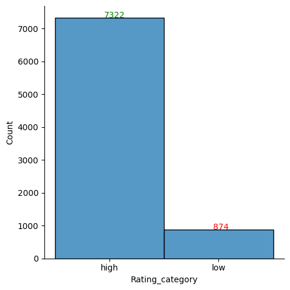

```python
sns.displot(data["Rating_category"])
plt.text(x=-0.05, y= data['Rating_category'].value_counts()[0], c="green", s=data['Rating_category'].value_counts()[0])  #+1,+2 used after 0 to give space b/w bar and number
plt.text(x=0.95, y= data['Rating_category'].value_counts()[1], c="red", s=data['Rating_category'].value_counts()[1])
#plt.text(x=0.98, y= tips_data['smoker'].value_counts()[1]+1, c="red", s="Ninety-Three")
plt.show()
```

**As the new column "Rating_category" is a categorical column so we can't see any distribution only barplot could be seen or dsplot with two bars as there are two categories high and low.**

### 8. Convert the column "Reviews'' to numeric data type and check the presence of outliers in the column and handle the outliers using a transformation approach.(Hint: Use log transformation)

```python
# Checking how many numeric values are there
data['Reviews'].str.isnumeric().sum()
```

```
8196
```

```python
# Converting reviews datatype to int(numeric)
data['Reviews'] = data['Reviews'].astype(int)
```

```python
data["Reviews"].dtype
```

```
dtype('int32')
```

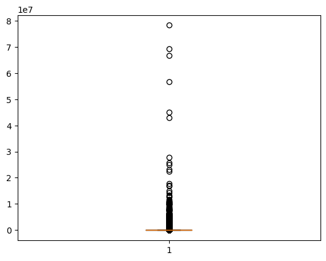

```python
#Checking outliers through boxplot
plt.boxplot(data["Reviews"])
plt.show()
```

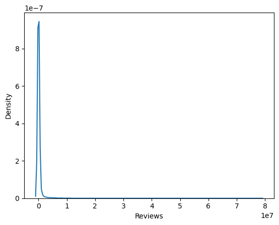

```python
#checking distribution through kde plot
sns.kdeplot(data["Reviews"])
plt.show()
```

**We can clearly see that "Reviews" data is highly skewed towards right. There is positive skewness and lot of outliers are present in the data. So we'll try to normalize data with help of log transformation.**

```python
#Using log10 to transform data to normal
data["Reviews"] = np.log10(data["Reviews"])
data["Reviews"]
```

```
0        2.201397
1        2.985426
2        4.942058
3        5.333737
4        2.985426
           ...
10834    0.845098
10836    1.579784
10837    0.602060
10839    2.056905
10840    5.600218
Name: Reviews, Length: 8196, dtype: float64
```

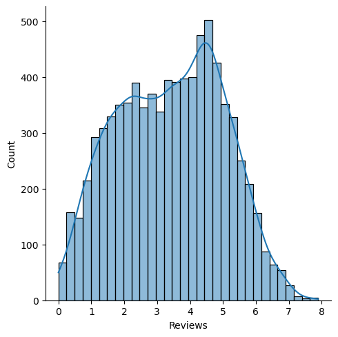

```python
#Checking data pot
sns.displot(data["Reviews"], kde=True)
plt.show()
```

**We can see that with help of log transformation the "Reviews column data is normalized to great extent**

### 9. The column 'Size' contains alphanumeric values, treat the non numeric data and convert the column into suitable data type. (hint: Replace M with 1 million and K with 1 thousand, and drop the entries where size='Varies with device')

```python
#We first use the replace() method to replace K, k, M and Varies with device with *1e3, *1e6 and 0, respectively:
#Next, we mathematically evaluate each value using map(pd.eval): and then using astype(int) we convert it to numeric
data["Size"]=data["Size"].replace({"K":"*1e3","k":"*1e3", "M":"*1e6", "Varies with device" :"0" }, regex=True).map(pd.eval).astype(int)
```

```python
#data["Size"].unique()
```

```python
#We had replaced varies with device with 0 so we'll drop all with 0
todrop = data[data["Size"] == 0].index
todrop.nunique()
```

```
1169
```

```python
#Dropping all rows where 0. 1169 rows will be dropped out of 8196
data.drop(todrop, inplace=True)
```

```python
data.shape
```

```
(7027, 14)
```

**After replacing and converting size column into numeric and dropping all rows with Varies with device we are left with 7027 rows.**

### 10. Check the column 'Installs', treat the unwanted characters and convert the column into a suitable data type.

```python
data["Installs"].value_counts()
```

```
1,000,000+        1175
100,000+           989
10,000+            948
1,000+             674
10,000,000+        646
500,000+           461
5,000,000+         450
50,000+            427
5,000+             413
100+               297
500+               195
50,000,000+        111
100,000,000+        96
10+                 67
50+                 56
5+                   9
500,000,000+         8
1+                   3
1,000,000,000+       2
Name: Installs, dtype: int64
```

```python
#Iterating through for loop to remove + and , signs from the data
char_to_remove = ["+" , ","]
for char in char_to_remove:
    data["Installs"] = data["Installs"].str.replace(char, "")
```

```python
#All unwanted characters removed
data["Installs"].unique()
```

```
array(['10000', '500000', '5000000', '50000000', '100000', '50000',
       '1000000', '10000000', '5000', '100000000', '1000', '500000000',
       '100', '500', '10', '1000000000', '5', '50', '1'], dtype=object)
```

```python
#Convertig data back to numerical
data["Installs"] = data["Installs"].astype(int)
print(data["Installs"].dtype)
```

```
int32
```

### 11. Check the column 'Price' , remove the unwanted characters and convert the column into a suitable data type.

```python
data["Price"].unique()
```

```
array(['0', '$4.99', '$6.99', '$7.99', '$3.99', '$5.99', '$2.99', '$1.99',
       '$9.99', '$0.99', '$9.00', '$5.49', '$10.00', '$24.99', '$11.99',
       '$79.99', '$16.99', '$14.99', '$29.99', '$12.99', '$3.49',
       '$10.99', '$7.49', '$1.50', '$19.99', '$15.99', '$33.99', '$39.99',
       '$2.49', '$4.49', '$1.70', '$1.49', '$3.88', '$399.99', '$17.99',
       '$400.00', '$3.02', '$1.76', '$4.84', '$4.77', '$1.61', '$1.59',
       '$6.49', '$1.29', '$299.99', '$379.99', '$37.99', '$18.99',
       '$389.99', '$8.49', '$1.75', '$14.00', '$2.00', '$3.08', '$2.59',
       '$19.40', '$15.46', '$8.99', '$3.04', '$13.99', '$4.29', '$3.28',
       '$4.60', '$1.00', '$2.90', '$1.97', '$2.56', '$1.20'], dtype=object)
```

```python
#Replacing $ with blank
data["Price"] = data["Price"].str.replace("$", "")
```

```python
#Al $ signs removed
data["Price"].unique()
```

```
array(['0', '4.99', '6.99', '7.99', '3.99', '5.99', '2.99', '1.99',
       '9.99', '0.99', '9.00', '5.49', '10.00', '24.99', '11.99', '79.99',
       '16.99', '14.99', '29.99', '12.99', '3.49', '10.99', '7.49',
       '1.50', '19.99', '15.99', '33.99', '39.99', '2.49', '4.49', '1.70',
       '1.49', '3.88', '399.99', '17.99', '400.00', '3.02', '1.76',
       '4.84', '4.77', '1.61', '1.59', '6.49', '1.29', '299.99', '379.99',
       '37.99', '18.99', '389.99', '8.49', '1.75', '14.00', '2.00',
       '3.08', '2.59', '19.40', '15.46', '8.99', '3.04', '13.99', '4.29',
       '3.28', '4.60', '1.00', '2.90', '1.97', '2.56', '1.20'],
      dtype=object)
```

```python
#Convertig data back to numerical
data["Price"] = data["Price"].astype(float)
print(data["Price"].dtype)
```

```
float64
```

### 12. Drop the columns which you think redundant for the analysis.(suggestion: drop column 'rating', since we created a new feature from it (i.e. rating_category) and the columns 'App', 'Rating' ,'Genres','Last Updated', 'Current Ver','Android Ver' columns since which are redundant for our analysis)

```python
data.columns
```

```
Index(['App', 'Category', 'Rating', 'Reviews', 'Size', 'Installs', 'Type',
       'Price', 'Content Rating', 'Genres', 'Last Updated', 'Current Ver',
       'Android Ver', 'Rating_category'],
      dtype='object')
```

```python
#Dropping redundant columns
data.drop(data[['Rating', 'App', 'Genres', 'Last Updated', 'Current Ver', 'Android Ver']], axis=1, inplace=True)
data.shape
```

```
(7027, 8)
```

**After removing all redundant columns we are left with 8 columns/features out of 14**

### 13. Encode the categorical columns.

```python
data["Category"].unique()
```

```
array(['ART_AND_DESIGN', 'AUTO_AND_VEHICLES', 'BEAUTY',
       'BOOKS_AND_REFERENCE', 'BUSINESS', 'COMICS', 'COMMUNICATION',
       'DATING', 'EDUCATION', 'ENTERTAINMENT', 'EVENTS', 'FINANCE',
       'FOOD_AND_DRINK', 'HEALTH_AND_FITNESS', 'HOUSE_AND_HOME',
       'LIBRARIES_AND_DEMO', 'LIFESTYLE', 'GAME', 'FAMILY', 'MEDICAL',
       'SOCIAL', 'SHOPPING', 'PHOTOGRAPHY', 'SPORTS', 'TRAVEL_AND_LOCAL',
       'TOOLS', 'PERSONALIZATION', 'PRODUCTIVITY', 'PARENTING', 'WEATHER',
       'VIDEO_PLAYERS', 'NEWS_AND_MAGAZINES', 'MAPS_AND_NAVIGATION'],
      dtype=object)
```

```python
data["Type"].unique()
```

```
array(['Free', 'Paid'], dtype=object)
```

```python
data["Content Rating"].unique()
```

```
array(['Everyone', 'Teen', 'Everyone 10+', 'Mature 17+',
       'Adults only 18+', 'Unrated'], dtype=object)
```

```python
data["Rating_category"].unique()
```

```
array(['high', 'low'], dtype=object)
```

```python
#Changed high with 1 and low with because it will be used for model training
data["Rating_category"] = data["Rating_category"].map({"high":1, "low":0})
```

```python
data = pd.get_dummies(data, columns=["Category", "Type", "Content Rating"],drop_first=True)
data.shape
```

```
(7027, 43)
```

**With get dummies we have encoded all categorical variables and dropped first, so we now have 43 columns with 7027 rows**

### 14. Segregate the target and independent features (Hint: Use Rating_category as the target)

```python
X = data.drop("Rating_category", axis=1)
y = data[["Rating_category"]]
print(X.columns)
```

```
Index(['Reviews', 'Size', 'Installs', 'Price', 'Category_AUTO_AND_VEHICLES',
       'Category_BEAUTY', 'Category_BOOKS_AND_REFERENCE', 'Category_BUSINESS',
       'Category_COMICS', 'Category_COMMUNICATION', 'Category_DATING',
       'Category_EDUCATION', 'Category_ENTERTAINMENT', 'Category_EVENTS',
       'Category_FAMILY', 'Category_FINANCE', 'Category_FOOD_AND_DRINK',
       'Category_GAME', 'Category_HEALTH_AND_FITNESS',
       'Category_HOUSE_AND_HOME', 'Category_LIBRARIES_AND_DEMO',
       'Category_LIFESTYLE', 'Category_MAPS_AND_NAVIGATION',
       'Category_MEDICAL', 'Category_NEWS_AND_MAGAZINES', 'Category_PARENTING',
       'Category_PERSONALIZATION', 'Category_PHOTOGRAPHY',
       'Category_PRODUCTIVITY', 'Category_SHOPPING', 'Category_SOCIAL',
       'Category_SPORTS', 'Category_TOOLS', 'Category_TRAVEL_AND_LOCAL',
       'Category_VIDEO_PLAYERS', 'Category_WEATHER', 'Type_Paid',
       'Content Rating_Everyone', 'Content Rating_Everyone 10+',
       'Content Rating_Mature 17+', 'Content Rating_Teen',
       'Content Rating_Unrated'],
      dtype='object')
```

### 15. Split the dataset into train and test.

```python
#Using sklearn model selection I divided the data into train and test
X_train, X_test, y_train, y_test = train_test_split(X,y, test_size = 0.30, random_state = 1)
```

### 16. Standardize the data, so that the values are within a particular range.

```python
#Scales the data. Essentially returns the z-scores of every attribute
std_scale = StandardScaler()
std_scale
```

```
StandardScaler()
```

```python
X_train = std_scale.fit_transform(X_train)
X_test = std_scale.fit_transform(X_test)
y_train = std_scale.fit_transform(y_train)
y_test = std_scale.fit_transform(y_test)
```

```python
X_train
```

```
array([[ 1.33984806,  2.86191899,  0.2015574 , ..., -0.21329134,
        -0.35302748, -0.014261  ],
       [ 0.53593007,  2.10548901, -0.15529026, ..., -0.21329134,
        -0.35302748, -0.014261  ],
       [-0.01589245,  0.94859611, -0.15529026, ..., -0.21329134,
        -0.35302748, -0.014261  ],
       ...,
       [-0.34902154, -0.43077619, -0.15709252, ..., -0.21329134,
        -0.35302748, -0.014261  ],
       [ 0.8215158 , -0.29728855,  0.02133131, ..., -0.21329134,
        -0.35302748, -0.014261  ],
       [ 0.54563056, -0.11930503, -0.12284957, ..., -0.21329134,
         2.83264068, -0.014261  ]])
```

```python
X_test
```

```
array([[-6.46465930e-01, -9.30745983e-01, -1.79362020e-01, ...,
        -2.11131530e-01, -3.53270435e-01,  0.00000000e+00],
       [-1.15193017e+00, -8.16575866e-01, -1.79362020e-01, ...,
        -2.11131530e-01, -3.53270435e-01,  0.00000000e+00],
       [ 1.11494190e+00,  3.21707798e-03,  1.52694821e-02, ...,
        -2.11131530e-01, -3.53270435e-01,  0.00000000e+00],
       ...,
       [ 1.46727354e+00,  1.41961326e+00,  2.10095810e-01, ...,
        -2.11131530e-01, -3.53270435e-01,  0.00000000e+00],
       [ 1.24121785e+00,  5.18270237e-01, -1.40591580e-01, ...,
         4.73638399e+00, -3.53270435e-01,  0.00000000e+00],
       [ 4.63142256e-01, -6.27723042e-01, -1.60074213e-01, ...,
        -2.11131530e-01, -3.53270435e-01,  0.00000000e+00]])
```

```python
y_train
```

```
array([[0.3552092],
       [0.3552092],
       [0.3552092],
       ...,
       [0.3552092],
       [0.3552092],
       [0.3552092]])
```

```python
y_test
```

```
array([[ 0.38154038],
       [ 0.38154038],
       [-2.62095459],
       ...,
       [ 0.38154038],
       [ 0.38154038],
       [ 0.38154038]])
```